# Jupyter / IPython sihirli ifadeler

Jupyter

Author

Kaan Öztürk

Published

November 28, 2017

Jupyter Jupyter olmadan önce (yani birçok farklı dil çekirdeğiyle uyumlu bir arayüz haline gelmeden önce) *IPython Notebook* olarak biliniyordu. IPython bir Python yorumlayıcısı, ama özellikle etkileşimli sayısal hesaplamalar gözetilerek hazırlanmış bir yorumlayıcı. Başta sadece terminalde çalışıyordu, daha sonra Web teknolojileriyle birleştirilerek tarayıcı içinde kullanılabilen bir *defter* yapısına kavuştu.

[Geçmiş bir yazıda bahsettiğimiz](http://www.veridefteri.com/2017/10/30/jupyter-notebook-nedir-2/) *Jupyter* arayüzünün özellikleri doğrudan doğruya *IPython*’dan alınmış, ve yorumlanabilir herhangi bir dille çalışabilecek şekilde genelleştirilmiştir. *Jupyter*’in devraldığı *IPython* özelliklerinden biri de **sihirli ifadeler** denen bazı kolaylaştırıcı, özelleşmiş komutlardır. Bu komutlar `!`, `%` veya `%%` ile başlarlar. Sihirli ifadeler Python yorumlayıcısına aktarılmadan *IPython* tarafından işlenir.

Sihirli ifadeler IPython çekirdeğine özgü oldukları için sadece Python ile çalışırlar. Jupyter’in desteklediği diğer diller (R, Julia, vd.) şimdilik bu özelliğe sahip değiller.

Sihirli ifadelerle ilgili tam referans için [resmi belgelere bakabilirsiniz.](http://ipython.readthedocs.io/en/stable/interactive/magics.html) Bu yazıda bazı en yaygın kullanılan komutlara göz atacağız.

## Sistem komutu çalıştırmak

İşletim sisteminin komut yorumlayıcısına doğrudan erişmek için `!` sihrini kullanırız. Bu komutların cevabı ekrana yazılır. (Dikkat: Aşağıdaki örnekler bir Linux sisteminde çalışır. Windows veya MacOS’da çalışıyorsanız, sisteminizdeki kabuğa uygun komutlar denemelisiniz.)

Tarih ve saat:

```python
!date
```

```
Cum 17 Kas 2023 15:23:08 +03
```

`ls` ile `\bin` dizininde z ile başlayan dosyaları görelim.

```python
!ls /bin/z*
```

```
/bin/zcat    /bin/zfgrep      /bin/zipgrep    /bin/zmore     /bin/zstdless
/bin/zcmp    /bin/zforce      /bin/zipinfo    /bin/znew      /bin/zstdmt
/bin/zdiff   /bin/zgrep       /bin/zipnote    /bin/zoom
/bin/zdump   /bin/zip         /bin/zipsplit   /bin/zstd
/bin/zegrep  /bin/zipcloak    /bin/zjsdecode  /bin/zstdcat
/bin/zenity  /bin/zipdetails  /bin/zless      /bin/zstdgrep
```

Bu komutların çıktılarını, daha sonra kullanmak için bir değişkene atayabiliriz. Bu şekilde, komut satırında kolayca yapılabilecek bir iş için kod yazmak zorunda kalmayız.

```python
bindosyalar = !ls /bin/z*
bindosyalar
```

```
['/bin/zcat',
 '/bin/zcmp',
 '/bin/zdiff',
 '/bin/zdump',
 '/bin/zegrep',
 '/bin/zenity',
 '/bin/zfgrep',
 '/bin/zforce',
 '/bin/zgrep',
 '/bin/zip',
 '/bin/zipcloak',
 '/bin/zipdetails',
 '/bin/zipgrep',
 '/bin/zipinfo',
 '/bin/zipnote',
 '/bin/zipsplit',
 '/bin/zjsdecode',
 '/bin/zless',
 '/bin/zmore',
 '/bin/znew',
 '/bin/zoom',
 '/bin/zstd',
 '/bin/zstdcat',
 '/bin/zstdgrep',
 '/bin/zstdless',
 '/bin/zstdmt']
```

## Yardım almak

Jupyter’in çevrimiçi yardımını hücre sihirleriyle de kullanabilirsiniz. Sihirli kelimeyi yazıp `Shift-Tab` bastığınızda bir yardım balonu çıkar.

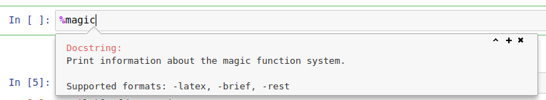

Sihirli ifadelerin kullanımının özeti ve her bir komutun kısa açıklaması için `%quickref` komutunu, tam ve kapsamlı bir referans için `%magic` komutunu kullanabilirsiniz.

**Satır sihirleri** bir tek `%` işaretiyle başlar, ve tek satırda bulunurlar. Hücrenin geri kalanında Python kodu bulunabilir. **Hücre sihirleri** ise çift `%%` işaretiyle başlarlar. Hücrenin tamamı bu sihrin etkisinde kalır.

## %time, %timeit: Süre ölçme

Bir komutun işletilmesinin ne kadar zaman aldığını ölçmek için `%time` ve `%timeit` sihirlerini kullanabiliriz. Bunlar standart kütüphanedeki `time` ve `timeit` modüllerini kullanır.

```python
%time sum(range(1000))
```

```
CPU times: user 27 µs, sys: 4 µs, total: 31 µs
Wall time: 35.5 µs
```

```
499500
```

Ancak, bilgisayar sistemi bazı anlarda başka işlerle meşgul olabildiği için bir tek süre ölçümü yanıltıcı olabilir. `%timeit`, komutu bir döngü içinde birçok defa çalıştırır, bunların ortalama süresini bulur. Bunu birkaç defa tekrarlar ve elde ettiği sonuçların ortalama ve standart sapma olarak verir.

```python
%timeit sum(range(1000))
```

```
15.6 µs ± 482 ns per loop (mean ± std. dev. of 7 runs, 100,000 loops each)
```

Döngü sayısı açıkça verilmediyse, otomatik olarak ayarlanır. Döngü sayısı, toplam çalışma süresi 0.2 saniyenin üstünde olacak şekilde 10’un kuvvetleri olarak belirlenir. Döngü sayısı ve tekrar sayısı istendiği gibi değiştirilebilir.

```python
%timeit -n 250 -r 4 sum(range(1000))
```

```
20.2 µs ± 795 ns per loop (mean ± std. dev. of 4 runs, 250 loops each)
```

Süresini tutmak istediğimiz işlem birkaç satıra yayılmış olabilir. O zaman bütün hücrenin işleyiş süresini ölçmek için, çift yüzde işaretiyle, `%%timeit` *hücre sihiri* kullanırız.

Örnek olarak, bir listeyi `append` ile genişletmek ve liste kurma arasındaki zaman farkına bakalım.

```python
%%timeit -r 10
L = []
for i in range(1000):
    L.append(i**2)
```

```
239 µs ± 2.34 µs per loop (mean ± std. dev. of 10 runs, 1,000 loops each)
```

```python
%timeit -r 10 [i**2 for i in range(1000)]
```

```
210 µs ± 1.53 µs per loop (mean ± std. dev. of 10 runs, 1,000 loops each)
```